# A3: SPL Library Checkouts

### The Dataset

#### Who collected/published the data?

This data was collected and published by The Seattle Public Library. It was first created on January 31st, 2017 and was last updated on March 6th 2023.

#### What are the parameters of the data (dates, number of checkouts, kinds of books, etc.)?

This data consists of 12 columns representing its main categories. These columns consist of: - UsageClass (If the item is physical or digital) - CheckoutType (What tool was used to check the item out) - MaterialType (What kind of item was checked out) - CheckoutYear (Year checked out) - CheckoutMonth (Month checked out) - Checkouts (Number of times item was checked out) - Title (Title, and possible subtitle of item) - ISBN (Any ISBNS associated with the item) - Creator (The author behind the item) - Subjects (Any genres, topics, etc. associated with the item) - Publisher (Entity that published the item) - PublicationYear (Year published)

Taken from the SPL Website (Checkouts by Title | City of Seattle Open Data Portal, 2023).

All of these categories range from 2013 to 2023, depending on the dataset chosen.

#### How was the data collected or generated?

The each checkout and its metadata was recording through the utilization of the checkout type backlogging said data to be uploaded after the fact.

#### Why was the data collected?

This data was collected and distributed to allow the general public to get a better sense of the trends surrounding content, their mediums, forms of acquirement, etc.

#### What, if any, ethical questions do you need to consider when working with this data?

One major question I found myself considering as I worked with this data lied in the curiosity as to how spreading data like this might shape the opinions of the masses when they go to checkout more content. Essentially, how might representing trends like popularity in content and the mediums they are conveyed shape the opinions of those viewing it, and could it create a minor mob mentality? Building off of that, how do we communicate this data from an objective standpoint to prevent something like that from happening?

#### What are possible limitations or problems with this data? (at least 200 words)

I think a key problem I found with this data in my time working with it was in the subject section. The subjects in this section seemed rather plastered, for lack of a better word, all over the place and made it rather difficult especially when conducting my fiction vs non-fiction analysis. Essentially, there was not a clear sense of hierarchy when communicating the subjects associated with an item. A limitation in this set lies in the time-range of the data. It would be very interesting to scale further back past 2013 to see how the interest in content changed as the digital era became more prominent. To do this, we’d need to scale back to the 1990s at the very least.

### First Trends Over Time Chart: Fiction vs. Nonfiction across 2022

I wanted to start with a very general topic that while a bit abstract, interested me. Throughout the course of 2022, the U.S. began to come out of quarantine, and I wanted to see how that may have affected how we consumed content from the SPL during this time. To add a comparision, I decided to compare fiction agaisnt nonfiction as my curiousity lead me to wonder how the exposure to more external factors like the outside world may affect what we end up wanting to consume, content-wise.

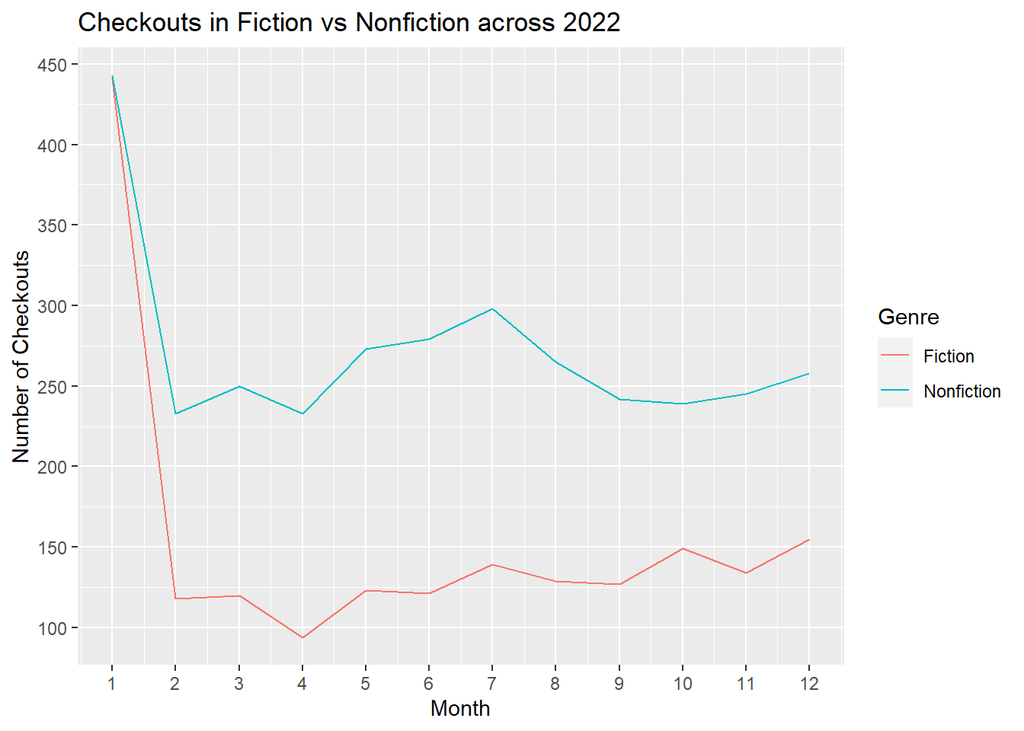

In making this chart, I found that both fiction and nonfiction checkouts started at a fairly similar number of checkouts, and while they both followed a similar pattern throughout the course of the year (spikes, drops, etc.) Nonfiction held at a higher number of checkouts for the entirety of the year.

### Second Trends Over Time Chart

My second chart relates again to my interest in Kevin Kwan. Given that his hit book *Crazy Rich Asians* came out in 2013, I decided to research the top-selling books in 2013 to find a competitor and found that, *Inferno* by Dan Brown was one of the bestselling books in 2013 (Reporter, 2017). In stacking Kwan’s number of checkouts against a competitor, I was curious to see how the fame of the film adaption of *Crazy Rich Asians* would compare against a popular author who mainly stuck to the medium of a book.

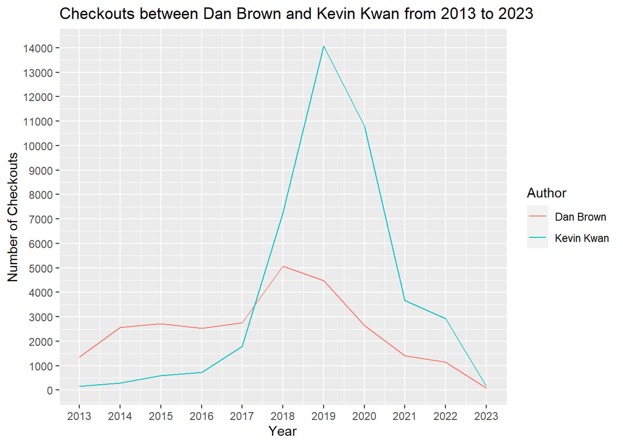

In this chart, you’ll see that while Brown has more checkouts than Kwan from 2013 to 2017, Kwan’s checkouts significantly increase and remain above Brown’s after the film adaption of *Crazy Rich Asians* releases. It is also interesting to note that both authors end up at a very similar number of checkouts as of 2023.

### Your Choice

For my last chart, I wanted to get a sense of the most popular item types being checked out from the Seattle Public Library were in 2022. In doing so, I found that the top 3 item types were: Mixed (Items like headphones, CD, etc.), Ebooks, and Audiobooks. From here, I decided to compare how much of each type were being checked out and compare them against each other in a pie chart.

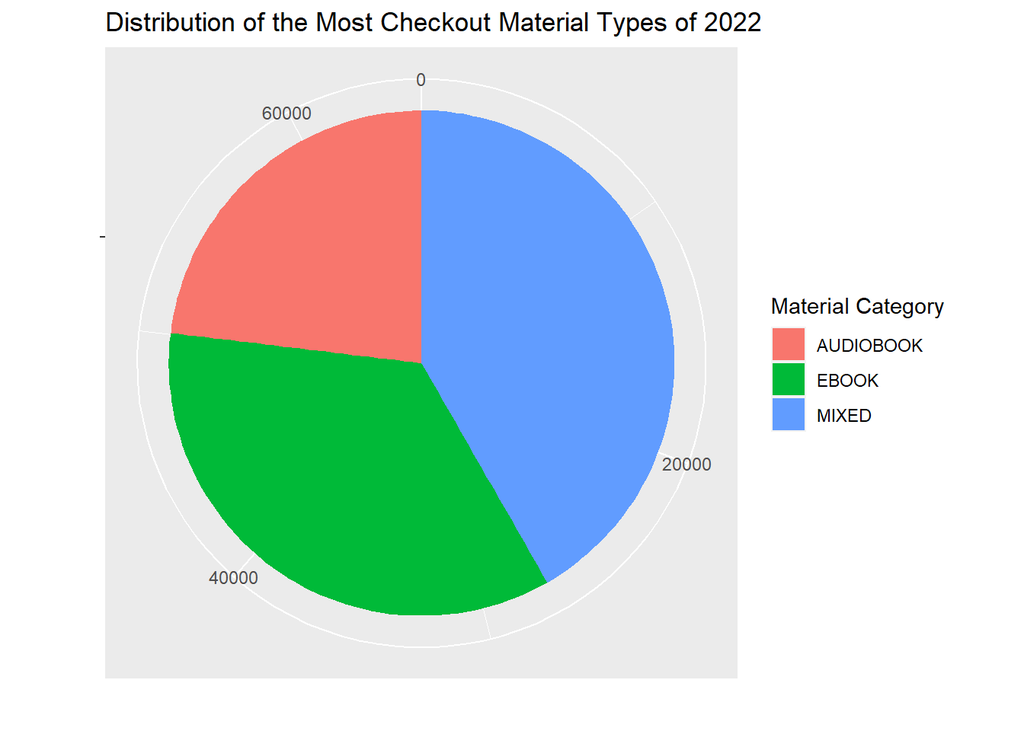

Here I found that the Mixed category was the most prevalent type being checked out. However, if you were to combine Ebooks and Audiobooks into the same category of books, then it would gain prevalence.

### References

Crazy Rich Asians (2018) - Release info - IMDb. (n.d.). IMDb. https://www.imdb.com/title/tt3104988/releaseinfo/

Checkouts by Title | City of Seattle Open Data portal. (2023, March 6). https://data.seattle.gov/Community/Checkouts-by-Title/tmmm-ytt6

Reporter, G. S. (2017, September 20). Bestselling books of 2013: the chart. The Guardian. https://www.theguardian.com/books/2013/dec/27/bestselling-print-books-2013